# Simulating a barrier with ms

Peter Ralph

May 4, 2015

A demographic model is a list of population models on the same grid, with a bit more information (time to switch for each). The way to build a demographic model is to:

1. Start with a grid,
2. then moving backwards in time, copy the last state,
3. then modify it.

The function `add_to_demography` does this copy-and-modify step; and demographic models can be modified directly by subsetting.

# Building the demographic model

## Initialization

First, let’s choose the parameters for the grid:

```r
nrow <- 30                # width of grid
ncol <- 20                # height of grid
barrier.time <- 3         # time ago the barrier ended
rejoin.time <- 5          # time ago the barrier began
barrier.rows <- c(10,20)  # locations of the barrier
```

Now, we will initialize the demographic model with a grid:

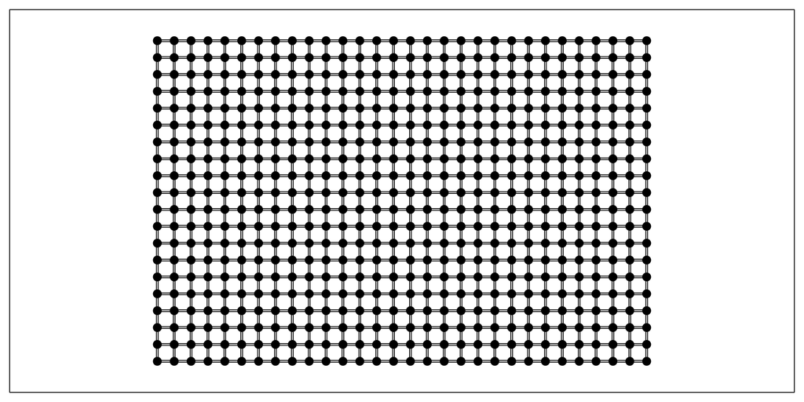

```r
dem <- demography( grid_array(nlayers=1,nrow=nrow,ncol=ncol,N=1,mig.rate=1) )
plot(dem[[1]])
```

## Add the barrier

Then, we copy-and-modify that first state, adding it to the demography: `add_to_demography` applies the function specified by `fn=` to a population state (by default the most recent one), with the extra parameters given, and appends it to the demography `dem`, at time given by `tnew`:

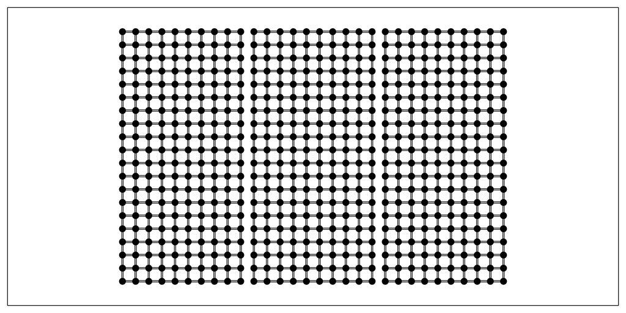

```r
dem <- add_to_demography( dem, tnew=barrier.time, fn=add_barrier, layer=1, rows=barrier.rows )
plot(dem[[2]])
```

## Remove the barrier

To remove the barrier, we’ll just set the state back to what it was before (this is `pop[[1]]`, the first state):

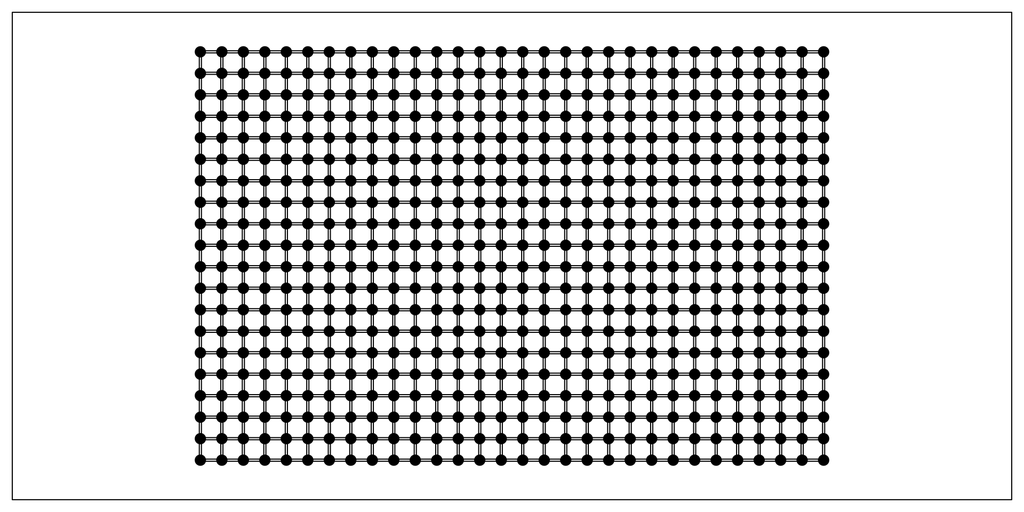

```r
dem <- add_to_demography( dem, tnew=rejoin.time, pop=dem[[1]] )
plot(dem[[3]])
```

# Simulating with ms

## Trees, in R

To turn this into the command-line parameters for `ms`, we first turn it into an `msarg` object, which is just a named list, but nicer to parse with `R` than just a big long string. This also needs to know now many samples we will take, and where (as `ms` does). `ms` needs the sample configuration as a giant long vector, but we keep track of it in a four-column matrix, (row, column, layer, number of samples).

```r
sample.config <- cbind(
    row=c(5,5,25,25),
    col=c(5,15,5,15),
    layer=c(1,1,1,1),
    n=c(2,2,2,2)
    )
sample.cols <- rainbow(nrow(sample.config))
sample.config
```

```
##      row col layer n
## [1,]   5   5     1 2
## [2,]   5  15     1 2
## [3,]  25   5     1 2
## [4,]  25  15     1 2
```

With this in hand, we can run `ms`. We’ll ask it to output trees, not sequence, and keep it all internal to `R` (by default it outputs to a new directory):

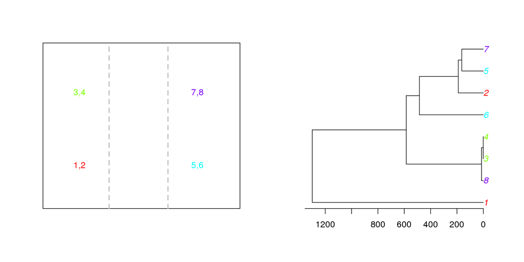

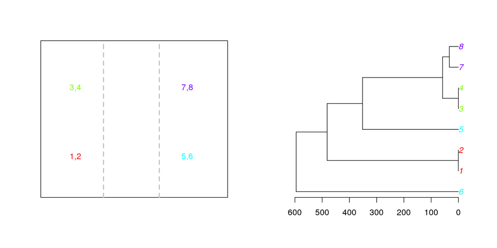

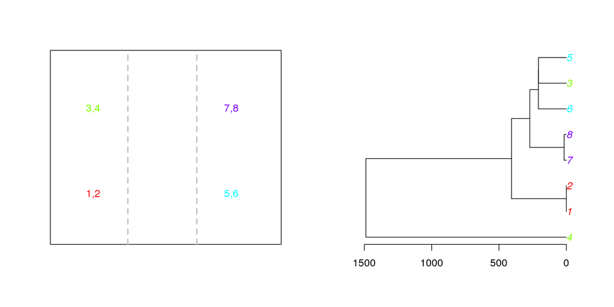

```r
ms.output <- suppressWarnings( run_ms( dem, nsamp=sample.config, trees=TRUE, tofile=FALSE, nreps=3 ) ) # never mind these warnings
tree.output <- trees_from_ms( ms.output )
layout(t(1:2))
for (tree in tree.output) {
    plot_sample_config( dem, sample.config )
    abline(v=barrier.rows, lty=2, lwd=2, col='grey')
    ape::plot.phylo( tree, tip.color=sample.cols[findInterval(as.numeric(tree$tip.label),1+c(0,cumsum(sample.config[,4])))] )
    ape::axisPhylo(1)
}
```

## Sequence, to a file

To get sequence, we could do as follows, this time outputting to a directory:

```r
ms.output <- run_ms( dem, nsamp=sample.config, theta=0.01 )
```

```
## Outputting to  msarg_168713  .
```

```r
cat(paste(scan(file.path(ms.output,"msoutput.txt"),what='char',sep='\n'),collapse='\n'))
```

```
## ms 8 1 -t 0.01 -f msarg_168713/msarg.txt
## 6681 49310 20512
## //
## segsites: 53
## positions: 0.0002 0.0023 0.0361 0.0484 0.0532 0.0536 0.0570 0.0652 0.0653 0.1035 0.1140 0.1268 0.1371 0.1422 0.2712 0.2782 0.2845 0.2861 0.3510 0.3534 0.3563 0.3595 0.3635 0.4096 0.4364 0.4763 0.5269 0.5381 0.5473 0.5474 0.5525 0.5668 0.6005 0.6400 0.6511 0.6609 0.6731 0.6833 0.6835 0.7031 0.7126…
## 01000010111010011010100100100000101010010000110100111
## 10000100000100100001000001011110000100101011001011000
## 01111001000011000110011010100001101011010100010100001
## 01111001000011000110001010100001101011010100010100001
## 01000010111010011010100100100000101010010000110100111
## 01000010100010010010100100100000111010010000010100101
## 01000010100010010010100100100000111010010000010100101
## 01000010100010010010100100100000111010010000010100101
```